# Chapter 17, Vignette 1: RSM predicted operating characteristics: lesDist and lesWghtDistr

Dev P. Chakraborty, PhD

2020-01-09

## Introduction

- The purpose of this vignette is to explain the operating characteristics predicted by the RSM. It relates to Chapter 17 in my book (Chakraborty 2017).
- This vignette is under development …
- Also to explain the difference between `dataset` members (`lesionID`, `lesionWeight`) and (`lesDist`, `lesWghtDistr`), which are RSM model parameters.

## The distinction between predicted curves and empirical curves

- Operating characteristics predicted by a model have zero sampling variability.
- Empirical operating characteristics, which apply to datasets, have non-zero sampling variability.
- If the model is corect, as the numbers of cases in the dataset increases, the empirical operating characteristic asymptotically approaches the predicted curve.

## The RSM model

- The 3 RSM parameters and two additional parameters characterizing the dataset determine the wAFROC curve.
- The 3 RSM parameters are $\mu$, $\lambda$ and $\nu$.
- The two dataset parameters are:
  - The distribution of number of lesions per diseased case, `lesDist`.
  - The distribution of lesion weights, `lesWghtDistr`.
- These parameters do not apply to individual cases; rather they refer to a large population (asymptotically infinite in size) of cases.

```r
str(dataset04$lesionID)
```

```
#>  num [1:100, 1:3] 1 1 1 1 1 1 1 1 1 1 ...
```

```r
str(dataset04$lesionWeight)
```

```
#>  num [1:100, 1:3] 1 1 1 1 1 1 1 1 1 1 ...
```

- Note that the first index of both arrays is the case index for the 100 abnormal cases in this dataset.
- With finite number of cases the empirical operating characteristic (or for that matter any fitted operating characteristic) will have sampling variability as in the following example.

## The empirical wAFROC

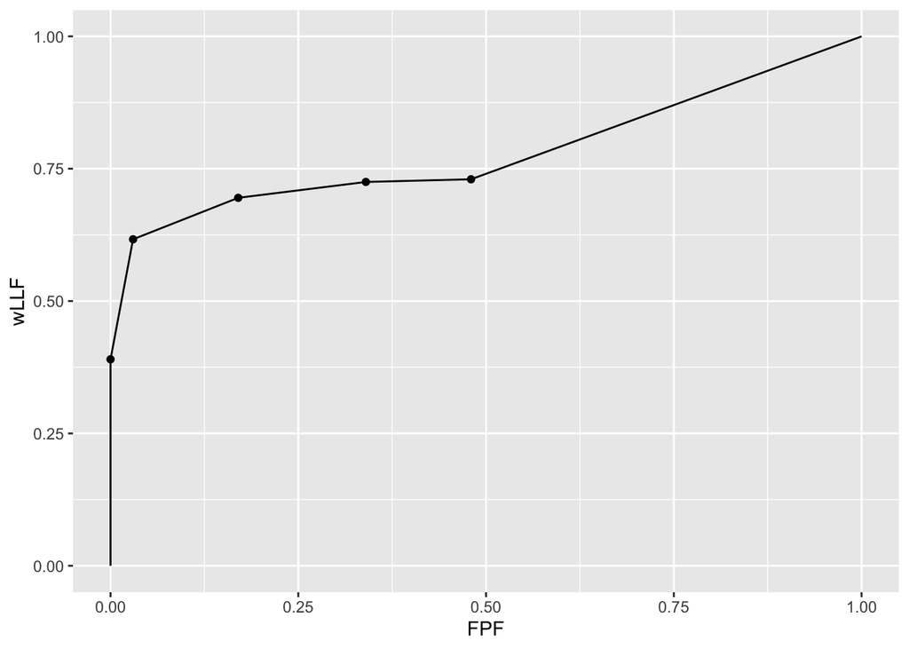

```r
p <- PlotEmpiricalOperatingCharacteristics(dataset04, opChType = "wAFROC")
p$Plot
```

- The piecewise linear nature of the plot, with sharp breaks, indicates that this is due to a finite dataset.
- In contrast the following code shows a smooth plot, because it is a model *predicted* plot.

## The predicted wAFROC

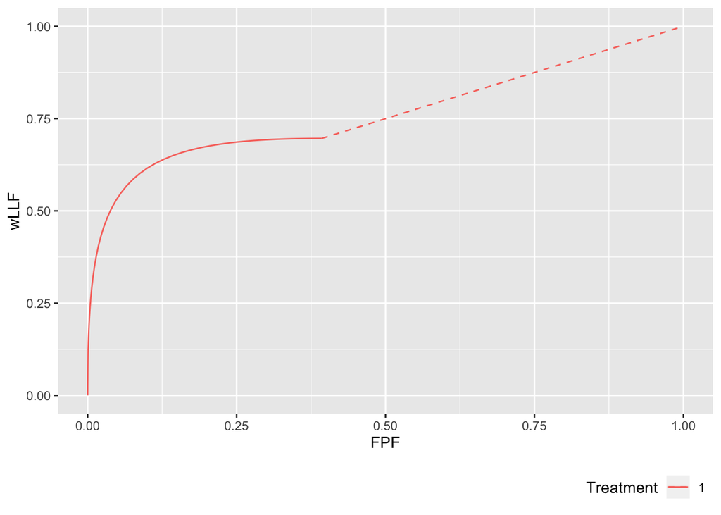

```r
## Following example is for mu = 2, lambda = 1, nu = 0.6. 20% of the diseased
## cases have a single lesion, 40% have two lesions, 10% have 3 lesions,
## and 30% have 4 lesions.
lesDistr <- rbind(c(1, 0.2), c(2, 0.4), c(3, 0.1), c(4, 0.3))

## On cases with one lesion the weights are 1, on cases with 2 lesions the weights
## are 0.4 and 0.6, on cases with three lesions the weights are 0.2, 0.3 and 0.5, and
## on cases with 4 lesions the weights are 0.3, 0.4, 0.2 and 0.1:
lesWghtDistr <- rbind(c(1, 1.0, -Inf, -Inf, -Inf),
                      c(2, 0.4,  0.6, -Inf, -Inf),
                      c(3, 0.2,  0.3,  0.5, -Inf),
                      c(4, 0.3,  0.4, 0.2,  0.1))
p <- PlotRsmOperatingCharacteristics(mu = 2, lambda = 1, nu = 0.6, OpChType = "wAFROC",
                                       lesDistr = lesDistr, lesWghtDistr = lesWghtDistr,
                                       legendPosition = "bottom", nlfRange = c(0, 1), llfRange = c(0, 1))
p$wAFROCPlot
```

## The distribution of number of lesions and weights

```r
lesDistr
```

```
#>      [,1] [,2]
#> [1,]    1  0.2
#> [2,]    2  0.4
#> [3,]    3  0.1
#> [4,]    4  0.3
```

```r
lesWghtDistr
```

```
#>      [,1] [,2] [,3] [,4] [,5]
#> [1,]    1  1.0 -Inf -Inf -Inf
#> [2,]    2  0.4  0.6 -Inf -Inf
#> [3,]    3  0.2  0.3  0.5 -Inf
#> [4,]    4  0.3  0.4  0.2  0.1
```

- The second column of `lesDistr` specifies the fraction of diseased cases with the number of lesions specified in the first column.
- The first column of `lesWghtDistr` is a copy of the first column of `lesDistr`. The remaining non-`-Inf` entries are the weights.
- For cases with 1 lesion, the weight is 1.
- For cases with 2 lesions, the first lesion has weight 0.4 and the second lesion has weight 0.6, which sum to unity.
- For cases with 3 lesions, the respective weights are 0.2, 0.3 and 0.5, which sum to unity.
- For cases with 4 lesions, the respective weights are 0.3, 0.4, 0.2 and 0.1, which sum to unity.

## Other operating characteristics

- By changing `OpChType` one can generate other operating characteristics.
- Note that lesiion weights argument is not needed for ROC curves. It is only needed for `wAFROC` and `wAFROC1` curves.

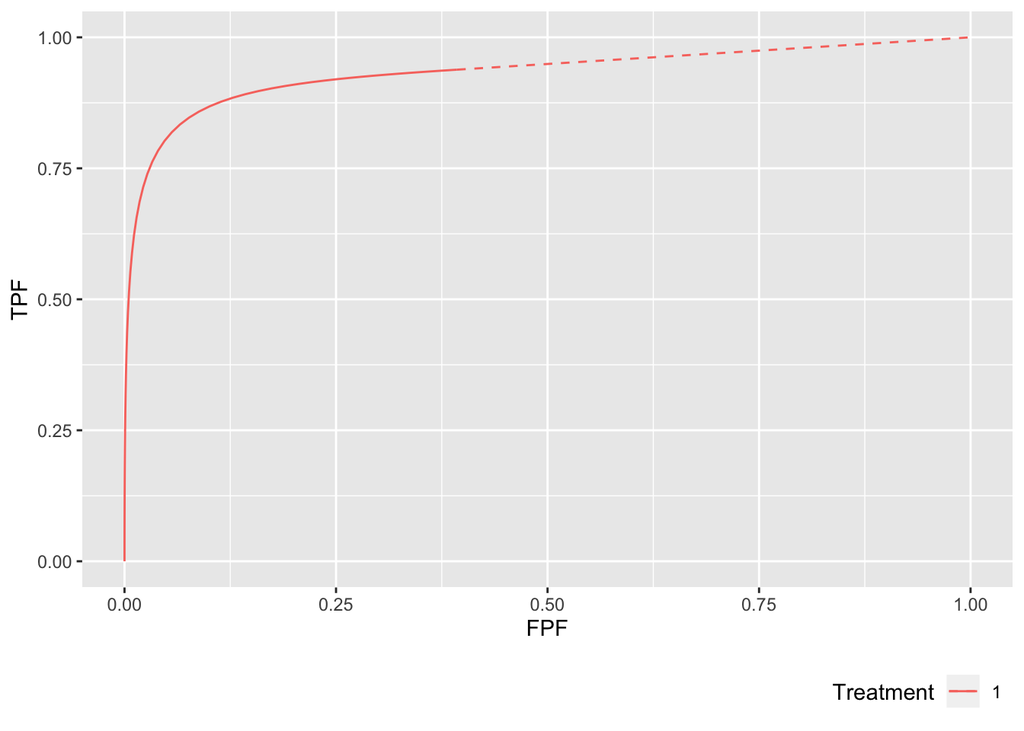

```r
lesDistr <- rbind(c(1, 0.2), c(2, 0.4), c(3, 0.1), c(4, 0.3))
p <- PlotRsmOperatingCharacteristics(mu = 2, lambda = 1, nu = 0.6, OpChType = "ROC",
                                       lesDistr = lesDistr,
                                       legendPosition = "bottom")
p$ROCPlot
```

## References

Chakraborty, Dev P. 2017. *Observer Performance Methods for Diagnostic Imaging - Foundations, Modeling, and Applications with R-Based Examples*. Book. Boca Raton, FL: CRC Press.